# Homework 5/Midterm

Andrew Wong

March 5, 2019

Git Repository: https://github.com/anwong024/compscix-415-2-assignments.git

```r
library(tidyverse)
library(mdsr)
```

# The tidyverse packages

## **1)**

plotting - ggplot2

Data munging/wrangling - dplyr

Reshaping (speading and gathering) data - tidyr

Importing/exporting data - readr

## **2)**

Plotting - ggplot(), geomsmooth()

Data munging/wrangling - select(), filter()

Reshaping data - spread(), gather()

Importing/exporting data - read_delim(), write_delim()

# R Basics

## **1)**

Original code: My_data.name___is.too00ooLong! <- c( 1 , 2 , 3 )

```r
My_data.name___is.too00ooLong <- c( 1 , 2   , 3 )#removed the exclimation mark.
```

## **2)**

Original code: my_string <- C(‘has’, ‘an’, ‘error’, ‘in’, ’it)

```r
my_string <- c('has', 'an', 'error', 'in', 'it') #used lower case 'c' and added quote to the final entry.
```

## **3)**

Because some of the values in my_vector are strings, R converts the rest in to strings.

# Data import/export

## **1)**

```r
rail_data <- read_delim('C:/Users/andy/downloads/rail_trail.txt', delim = '|')
glimpse(rail_data)
```

```
## Observations: 90
## Variables: 10
## $ hightemp   <dbl> 83, 73, 74, 95, 44, 69, 66, 66, 80, 79, 78, 65, 41,...
## $ lowtemp    <dbl> 50, 49, 52, 61, 52, 54, 39, 38, 55, 45, 55, 48, 49,...
## $ avgtemp    <dbl> 66.5, 61.0, 63.0, 78.0, 48.0, 61.5, 52.5, 52.0, 67....
## $ spring     <dbl> 0, 0, 1, 0, 1, 1, 1, 1, 0, 0, 0, 1, 1, 0, 0, 1, 0, ...
## $ summer     <dbl> 1, 1, 0, 1, 0, 0, 0, 0, 1, 1, 1, 0, 0, 0, 0, 0, 1, ...
## $ fall       <dbl> 0, 0, 0, 0, 0, 0, 0, 0, 0, 0, 0, 0, 0, 1, 1, 0, 0, ...
## $ cloudcover <dbl> 7.6, 6.3, 7.5, 2.6, 10.0, 6.6, 2.4, 0.0, 3.8, 4.1, ...
## $ precip     <dbl> 0.00, 0.29, 0.32, 0.00, 0.14, 0.02, 0.00, 0.00, 0.0...
## $ volume     <dbl> 501, 419, 397, 385, 200, 375, 417, 629, 533, 547, 4...
## $ weekday    <dbl> 1, 1, 1, 0, 1, 1, 1, 0, 0, 1, 1, 1, 1, 1, 1, 1, 0, ...
```

```r
write_delim(rail_data, delim = ',', 'C:/Users/andy/downloads/rail_trail.csv')
rail_data2 <- read_csv('C:/Users/andy/downloads/rail_trail.csv')
glimpse(rail_data2)
```

```
## Observations: 90
## Variables: 10
## $ hightemp   <dbl> 83, 73, 74, 95, 44, 69, 66, 66, 80, 79, 78, 65, 41,...
## $ lowtemp    <dbl> 50, 49, 52, 61, 52, 54, 39, 38, 55, 45, 55, 48, 49,...
## $ avgtemp    <dbl> 66.5, 61.0, 63.0, 78.0, 48.0, 61.5, 52.5, 52.0, 67....
## $ spring     <dbl> 0, 0, 1, 0, 1, 1, 1, 1, 0, 0, 0, 1, 1, 0, 0, 1, 0, ...
## $ summer     <dbl> 1, 1, 0, 1, 0, 0, 0, 0, 1, 1, 1, 0, 0, 0, 0, 0, 1, ...
## $ fall       <dbl> 0, 0, 0, 0, 0, 0, 0, 0, 0, 0, 0, 0, 0, 1, 1, 0, 0, ...
## $ cloudcover <dbl> 7.6, 6.3, 7.5, 2.6, 10.0, 6.6, 2.4, 0.0, 3.8, 4.1, ...
## $ precip     <dbl> 0.00, 0.29, 0.32, 0.00, 0.14, 0.02, 0.00, 0.00, 0.0...
## $ volume     <dbl> 501, 419, 397, 385, 200, 375, 417, 629, 533, 547, 4...
## $ weekday    <dbl> 1, 1, 1, 0, 1, 1, 1, 0, 0, 1, 1, 1, 1, 1, 1, 1, 0, ...
```

# Data Visualization

## **1)**

- The colors for the men and women graphics have their own color while the age graphics are the same color for no reason.
- Its not immediately clear that the numbers are percentages.
- The way the graphics are lined up, the Men and Women categories look like another age group.

## **2)**

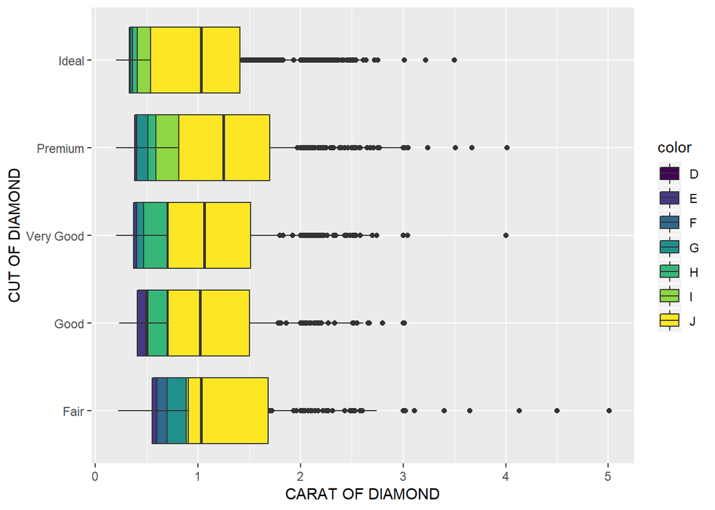

```r
ggplot(data = diamonds) +
     geom_boxplot(mapping = aes(x = cut, y = carat, fill = color), position = "identity") +
        coord_flip() + xlab("CUT OF DIAMOND") + ylab("CARAT OF DIAMOND" )
```

## **3)**

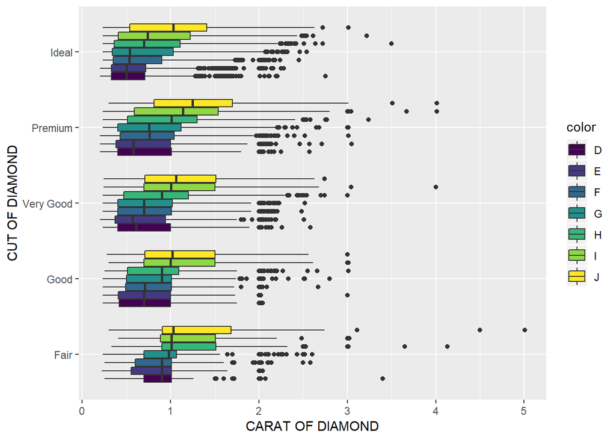

```r
ggplot(data = diamonds) +
     geom_boxplot(mapping = aes(x = cut, y = carat, fill = color)) +
        coord_flip() + xlab("CUT OF DIAMOND") + ylab("CARAT OF DIAMOND")
```

# Tidy Data

## **1)**

```r
table2 %>% spread(key = type, value = count)
```

```
## # A tibble: 6 x 4
##   country      year  cases population
##   <chr>       <int>  <int>      <int>
## 1 Afghanistan  1999    745   19987071
## 2 Afghanistan  2000   2666   20595360
## 3 Brazil       1999  37737  172006362
## 4 Brazil       2000  80488  174504898
## 5 China        1999 212258 1272915272
## 6 China        2000 213766 1280428583
```

## **2)**

diamonds %>% mutate(price_per_carat = price/carat)

## **3)**

```r
diamonds %>% group_by(cut) %>% summarize(over_10000_and_Under_1.5 = sum(price > 10000 & carat <1.5), prop = over_10000_and_Under_1.5/n())
```

```
## # A tibble: 5 x 3
##   cut       over_10000_and_Under_1.5    prop
##   <ord>                        <int>   <dbl>
## 1 Fair                             4 0.00248
## 2 Good                            17 0.00347
## 3 Very Good                      155 0.0128
## 4 Premium                        173 0.0125
## 5 Ideal                          485 0.0225
```

The results do not make sense. One would expect the number of diamonds priced above 10000 and below 1.5 carat to go down as cut quality went up since fewer high quality diamonds should have a low carat.

# EDA

## **1)**

```r
txhousing %>% distinct(year)
```

```
## # A tibble: 16 x 1
##     year
##    <int>
##  1  2000
##  2  2001
##  3  2002
##  4  2003
##  5  2004
##  6  2005
##  7  2006
##  8  2007
##  9  2008
## 10  2009
## 11  2010
## 12  2011
## 13  2012
## 14  2013
## 15  2014
## 16  2015
```

## **2)**

```r
txhousing %>% distinct(city)
```

```
## # A tibble: 46 x 1
##    city
##    <chr>
##  1 Abilene
##  2 Amarillo
##  3 Arlington
##  4 Austin
##  5 Bay Area
##  6 Beaumont
##  7 Brazoria County
##  8 Brownsville
##  9 Bryan-College Station
## 10 Collin County
## # ... with 36 more rows
```

## **3)**

```r
txhousing %>% select(year, month, city, sales) %>% arrange(desc(sales))
```

```
## # A tibble: 8,602 x 4
##     year month city    sales
##    <int> <int> <chr>   <dbl>
##  1  2015     7 Houston  8945
##  2  2006     6 Houston  8628
##  3  2013     7 Houston  8468
##  4  2015     6 Houston  8449
##  5  2013     5 Houston  8439
##  6  2014     6 Houston  8391
##  7  2014     7 Houston  8391
##  8  2014     8 Houston  8167
##  9  2013     8 Houston  8155
## 10  2006     5 Houston  8040
## # ... with 8,592 more rows
```

## **4)**

More listings will lead to more sales.

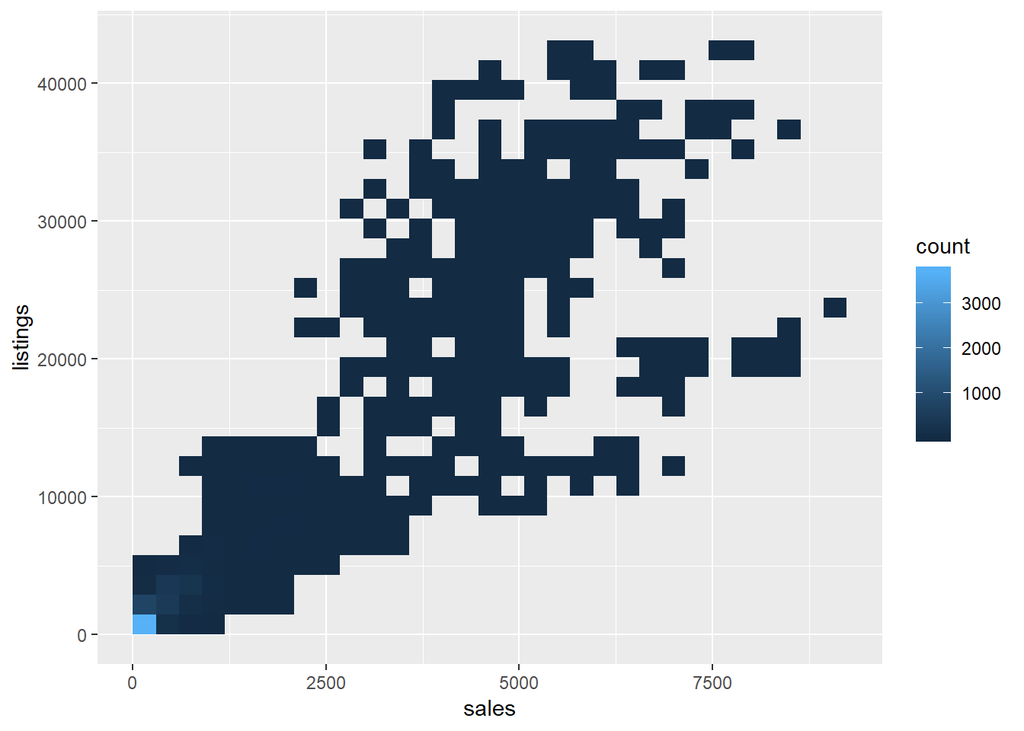

```r
txhousing %>% ggplot(mapping = aes(x = sales, y = listings)) + geom_bin2d(na.rm = TRUE)
```

## **5)**

```r
txhousing %>% group_by(city) %>% summarize(prop = sum(is.na(sales))/(sum(is.na(sales)) + sum(!is.na(sales))))
```

```
## # A tibble: 46 x 2
##    city                    prop
##    <chr>                  <dbl>
##  1 Abilene               0
##  2 Amarillo              0
##  3 Arlington             0
##  4 Austin                0
##  5 Bay Area              0
##  6 Beaumont              0
##  7 Brazoria County       0.0749
##  8 Brownsville           0.0107
##  9 Bryan-College Station 0
## 10 Collin County         0
## # ... with 36 more rows
```

## **6)**

```r
housing_filtered <-  txhousing %>% filter(sales > 500)
```

### Are the distributions of the median sales price (column name median), when grouped by city, different? The same?

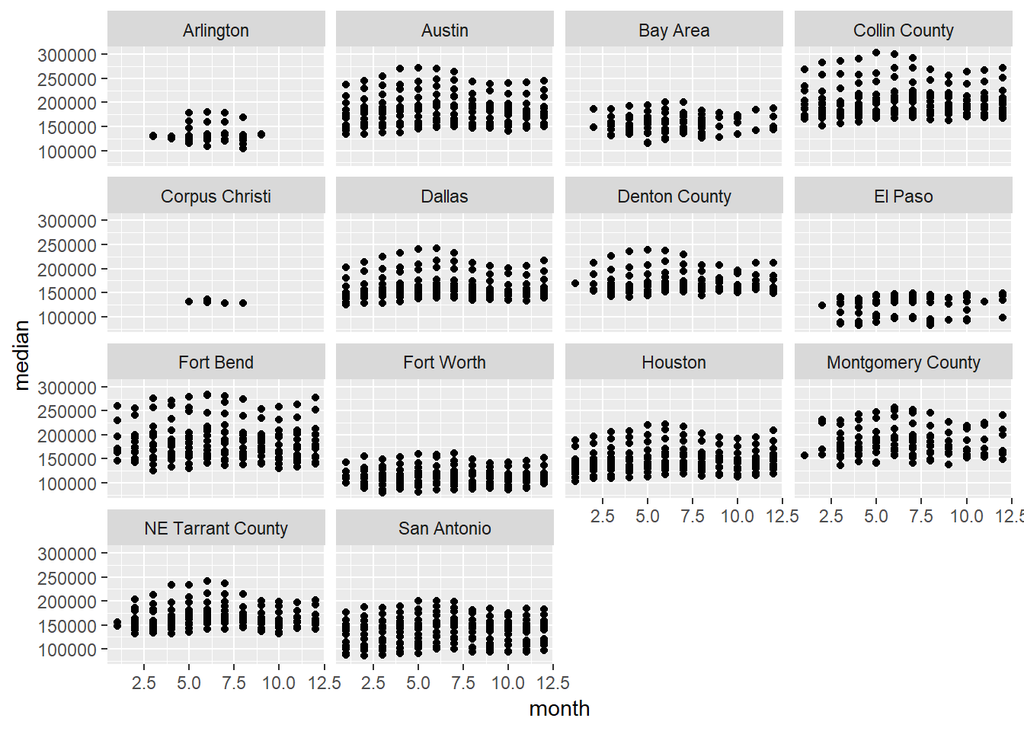

```r
housing_filtered %>% ggplot(mapping = aes(month, median)) + geom_point() + facet_wrap('city')
```

### Any cities that stand out that you’d want to investigate further?

Looking at the previous plot, Corpus Christi has far fewer points than other cities.

### Why might we want to filter out all cities and months with sales less than 500?

The data could be for real estate agencies who want to know the most popular places people want to live in and when they move.